# p7_2

```python
import pandas as pd
import numpy as np
import seaborn as sns
import matplotlib.pyplot as plt
import statsmodels.api as sm
import statsmodels.formula.api as smf
from scipy.stats import t, shapiro
from statsmodels.stats.outliers_influence import variance_inflation_factor
import statsmodels
```

```python
elast_gb_fini= pd.read_csv('C:\\Users\\HAYAT//p7_elast_gb_fini.csv')
elast_gb_final= pd.read_csv('C:\\Users\\HAYAT//p7_elast_gb_final.csv')
elast_gb_fini_log= pd.read_csv('C:\\Users\\HAYAT//p7_elast_gb_fini_log.csv')
```

```python
elast_gb_fini.head(3)
```

|  | Unnamed: 0 | pays | income | revenue_moyen | gini | c_i_parent |
| --- | --- | --- | --- | --- | --- | --- |
| 0 | 0 | Albania | 728.89795 | 2994.829902 | 0.311509 | 1 |
| 1 | 1 | Albania | 728.89795 | 2994.829902 | 0.311509 | 1 |
| 2 | 2 | Albania | 728.89795 | 2994.829902 | 0.311509 | 1 |

```python
elast_gb_fini=elast_gb_fini[['pays','income','revenue_moyen','gini','c_i_parent']]
elast_gb_fini.head(3)
```

|  | pays | income | revenue_moyen | gini | c_i_parent |
| --- | --- | --- | --- | --- | --- |
| 0 | Albania | 728.89795 | 2994.829902 | 0.311509 | 1 |
| 1 | Albania | 728.89795 | 2994.829902 | 0.311509 | 1 |
| 2 | Albania | 728.89795 | 2994.829902 | 0.311509 | 1 |

```python
elast_gb_final.head(3)
```

|  | Unnamed: 0 | pays | c_i_child | c_i_parent | income | gini | revenue_moyen | log_revenue_moyen | log_income |
| --- | --- | --- | --- | --- | --- | --- | --- | --- | --- |
| 0 | 0 | Albania | 1 | 1 | 728.89795 | 0.311509 | 2994.829902 | 8.004643 | 6.591534 |
| 1 | 1 | Albania | 1 | 1 | 728.89795 | 0.311509 | 2994.829902 | 8.004643 | 6.591534 |
| 2 | 2 | Albania | 1 | 1 | 728.89795 | 0.311509 | 2994.829902 | 8.004643 | 6.591534 |

```python
elast_gb_final=elast_gb_final[['pays','income','revenue_moyen','gini','log_income','log_revenue_moyen','c_i_parent']]
elast_gb_final.head(3)
```

|  | pays | income | revenue_moyen | gini | log_income | log_revenue_moyen | c_i_parent |
| --- | --- | --- | --- | --- | --- | --- | --- |
| 0 | Albania | 728.89795 | 2994.829902 | 0.311509 | 6.591534 | 8.004643 | 1 |
| 1 | Albania | 728.89795 | 2994.829902 | 0.311509 | 6.591534 | 8.004643 | 1 |
| 2 | Albania | 728.89795 | 2994.829902 | 0.311509 | 6.591534 | 8.004643 | 1 |

```python
elast_gb_fini_log.head(3)
```

|  | Unnamed: 0 | pays | log_income | log_revenue_moyen | gini | c_i_parent |
| --- | --- | --- | --- | --- | --- | --- |
| 0 | 0 | Albania | 6.591534 | 8.004643 | 0.311509 | 1 |
| 1 | 1 | Albania | 6.591534 | 8.004643 | 0.311509 | 1 |
| 2 | 2 | Albania | 6.591534 | 8.004643 | 0.311509 | 1 |

```python
elast_gb_fini_log=elast_gb_fini_log[['pays','log_income','log_revenue_moyen','gini','c_i_parent']]
```

```python
elast_gb_fini_log
```

|  | pays | log_income | log_revenue_moyen | gini | c_i_parent |
| --- | --- | --- | --- | --- | --- |
| 0 | Albania | 6.591534 | 8.004643 | 0.311509 | 1 |
| 1 | Albania | 6.591534 | 8.004643 | 0.311509 | 1 |
| 2 | Albania | 6.591534 | 8.004643 | 0.311509 | 1 |
| 3 | Albania | 6.591534 | 8.004643 | 0.311509 | 1 |
| 4 | Albania | 6.591534 | 8.004643 | 0.311509 | 1 |
| ... | ... | ... | ... | ... | ... |
| 3649995 | South Africa | 11.319444 | 8.633714 | 0.673048 | 100 |
| 3649996 | South Africa | 11.319444 | 8.633714 | 0.673048 | 100 |
| 3649997 | South Africa | 11.319444 | 8.633714 | 0.673048 | 100 |
| 3649998 | South Africa | 11.319444 | 8.633714 | 0.673048 | 100 |
| 3649999 | South Africa | 11.319444 | 8.633714 | 0.673048 | 100 |

3650000 rows × 5 columns

# ANOVA sur un facteur "pays"

Appliquez une ANOVA sur vos données, en n’incluant comme variable explicative que le pays de l’individu. Analysez la performance du modèle.On peut visualiser l'influence de la variété en affichant ces boîtes à moustaches :

```python
elast_gb_fini.pays.unique()
```

```
array(['Albania', 'Argentina', 'Armenia', 'Austria', 'Azerbaijan',
       'Belgium', 'Bulgaria', 'Belarus', 'Bolivia', 'Brazil',
       'Central African Republic', 'Canada', "Cote d'Ivoire", 'Colombia',
       'Costa Rica', 'Cyprus', 'Czech Republic', 'Germany', 'Denmark',
       'Dominican Republic', 'Ecuador', 'Spain', 'Estonia', 'Finland',
       'Fiji', 'France', 'United Kingdom', 'Georgia', 'Greece',
       'Honduras', 'Croatia', 'Hungary', 'Ireland', 'Iran, Islamic Rep.',
       'Iraq', 'Iceland', 'Israel', 'Italy', 'Jordan', 'Japan',
       'Kazakhstan', 'Kyrgyz Republic', 'Cambodia', 'Korea, Rep.',
       'Lithuania', 'Luxembourg', 'Latvia', 'Moldova', 'Mexico',
       'Macedonia, FYR', 'Montenegro', 'Mozambique', 'Mauritania',
       'Netherlands', 'Norway', 'Pakistan', 'Peru', 'Poland', 'Portugal',
       'Paraguay', 'Russian Federation', 'El Salvador', 'Serbia',
       'Slovak Republic', 'Slovenia', 'Sweden', 'Turkey', 'Taiwan, China',
       'Ukraine', 'Uruguay', 'United States', 'Yemen, Rep.',
       'South Africa'], dtype=object)
```

```python
listePays=['France','Brazil','Ukraine',"Cote d'Ivoire",'Italy']
```

```python
data_pays=elast_gb_fini[(elast_gb_fini['pays'].isin (listePays))]
data_pays
```

|  | pays | income | revenue_moyen | gini | c_i_parent |
| --- | --- | --- | --- | --- | --- |
| 450000 | Brazil | 144.02846 | 4807.484594 | 0.549004 | 1 |
| 450001 | Brazil | 144.02846 | 4807.484594 | 0.549004 | 1 |
| 450002 | Brazil | 144.02846 | 4807.484594 | 0.549004 | 1 |
| 450003 | Brazil | 144.02846 | 4807.484594 | 0.549004 | 1 |
| 450004 | Brazil | 144.02846 | 4807.484594 | 0.549004 | 1 |
| ... | ... | ... | ... | ... | ... |
| 3449995 | Ukraine | 11564.17100 | 3349.388306 | 0.262515 | 100 |
| 3449996 | Ukraine | 11564.17100 | 3349.388306 | 0.262515 | 100 |
| 3449997 | Ukraine | 11564.17100 | 3349.388306 | 0.262515 | 100 |
| 3449998 | Ukraine | 11564.17100 | 3349.388306 | 0.262515 | 100 |
| 3449999 | Ukraine | 11564.17100 | 3349.388306 | 0.262515 | 100 |

250000 rows × 5 columns

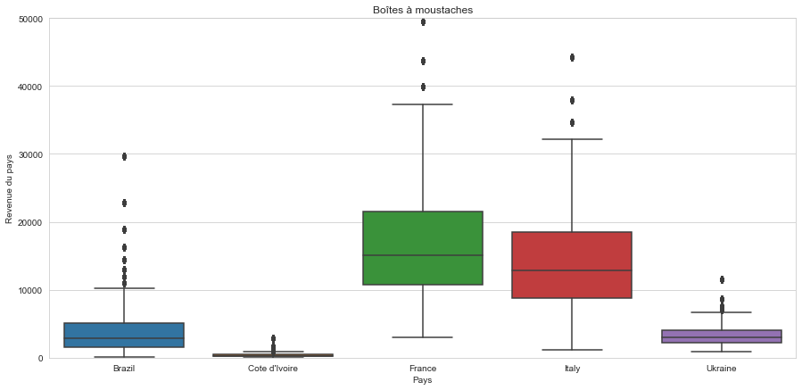

```python
sns.set_style("whitegrid")
plt.figure(figsize=(15, 7))
ax = sns.boxplot(x="pays", y="income", data=data_pays)


#sns.catplot(x="pays", y="income", data=data_pays, dodge=True, kind='box', aspect=5)
plt.xlabel('Pays')
plt.ylabel('Revenue du pays')
plt.title('Boîtes à moustaches')
plt.ylim(0,50000)
plt.savefig('p7_figures/dis_revenue_du_pays.png')
plt.show()
```

les revenues des pays semblent assez différentes grand écart suivant la logique de leurs classement par groupe de type de revenue : le pays semble être un facteur influant sur le revenue du pays? on poursuit notre analyse pour tester la significativité des écarts ou pasÉtudions maintenant l'influence du pays sur le revenue :on lance Anova

```python
anova_pays = smf.ols('income~pays', data=elast_gb_fini).fit()
print(anova_pays.summary())
```

```
                            OLS Regression Results
==============================================================================
Dep. Variable:                 income   R-squared:                       0.437
Model:                            OLS   Adj. R-squared:                  0.437
Method:                 Least Squares   F-statistic:                 3.935e+04
Date:                Tue, 14 Jun 2022   Prob (F-statistic):               0.00
Time:                        10:35:28   Log-Likelihood:            -3.8045e+07
No. Observations:             3650000   AIC:                         7.609e+07
Df Residuals:                 3649927   BIC:                         7.609e+07
Df Model:                          72
Covariance Type:            nonrobust
====================================================================================================
                                       coef    std err          t      P>|t|      [0.025      0.975]
----------------------------------------------------------------------------------------------------
Intercept                         2994.8299     36.396     82.285      0.000    2923.496    3066.164
pays[T.Argentina]                 2853.0548     51.471     55.430      0.000    2752.173    2953.936
pays[T.Armenia]                  -1366.4471     51.471    -26.548      0.000   -1467.329   -1265.565
pays[T.Austria]                   1.364e+04     51.471    265.057      0.000    1.35e+04    1.37e+04
pays[T.Azerbaijan]                -637.4009     51.471    -12.384      0.000    -738.283    -536.519
pays[T.Belarus]                    926.3336     51.471     17.997      0.000     825.452    1027.215
pays[T.Belgium]                   1.203e+04     51.471    233.719      0.000    1.19e+04    1.21e+04
pays[T.Bolivia]                     21.4339     51.471      0.416      0.677     -79.448     122.316
pays[T.Brazil]                    1812.6547     51.471     35.217      0.000    1711.773    1913.536
pays[T.Bulgaria]                  1990.1487     51.471     38.665      0.000    1889.267    2091.030
pays[T.Cambodia]                 -1508.4897     51.471    -29.307      0.000   -1609.371   -1407.608
pays[T.Canada]                    2.074e+04     51.471    403.037      0.000    2.06e+04    2.08e+04
pays[T.Central African Republic] -2183.5300     51.471    -42.422      0.000   -2284.412   -2082.648
pays[T.Colombia]                   552.1754     51.471     10.728      0.000     451.294     653.057
pays[T.Costa Rica]                2585.5567     51.471     50.233      0.000    2484.675    2686.438
pays[T.Cote d'Ivoire]            -2594.9947     51.471    -50.416      0.000   -2695.876   -2494.113
pays[T.Croatia]                   4721.6359     51.471     91.734      0.000    4620.754    4822.518
pays[T.Cyprus]                    1.435e+04     51.471    278.808      0.000    1.42e+04    1.45e+04
pays[T.Czech Republic]            5240.4635     51.471    101.814      0.000    5139.582    5341.345
pays[T.Denmark]                   1.405e+04     51.471    272.936      0.000    1.39e+04    1.41e+04
pays[T.Dominican Republic]         563.5722     51.471     10.949      0.000     462.691     664.454
pays[T.Ecuador]                    388.9111     51.471      7.556      0.000     288.029     489.793
pays[T.El Salvador]               -139.6051     51.471     -2.712      0.007    -240.487     -38.723
pays[T.Estonia]                   4707.2327     51.471     91.454      0.000    4606.351    4808.114
pays[T.Fiji]                      -896.0990     51.471    -17.410      0.000    -996.981    -795.217
pays[T.Finland]                   1.331e+04     51.471    258.620      0.000    1.32e+04    1.34e+04
```

[output cut: 41 more lines]

```
pays[T.Turkey]                    3055.6354     51.471     59.366      0.000    2954.754    3156.517
pays[T.Ukraine]                    354.5584     51.471      6.888      0.000     253.677     455.440
pays[T.United Kingdom]            1.871e+04     51.471    363.597      0.000    1.86e+04    1.88e+04
pays[T.United States]             2.251e+04     51.471    437.308      0.000    2.24e+04    2.26e+04
pays[T.Uruguay]                   2295.9550     51.471     44.607      0.000    2195.073    2396.837
pays[T.Yemen, Rep.]              -1952.1940     51.471    -37.928      0.000   -2053.076   -1851.312
==============================================================================
Omnibus:                  4079317.237   Durbin-Watson:                   0.001
Prob(Omnibus):                  0.000   Jarque-Bera (JB):        626742989.957
Skew:                           5.616   Prob(JB):                         0.00
Kurtosis:                      66.205   Cond. No.                         74.0
==============================================================================

Notes:
[1] Standard Errors assume that the covariance matrix of the errors is correctly specified.
```

## Réalisez un test de Fisher

```python
#ou est la p-value
```

l'hypothèse H0 selon laquelle $α_{1}=α_{2}=α_{3}....α_{n}=0$.

```python
tab_pays=sm.stats.anova_lm(anova_pays, typ=2)
tab_pays
```

|  | sum_sq | df | F | PR(>F) |
| --- | --- | --- | --- | --- |
| pays | 1.876461e+14 | 72.0 | 39349.469869 | 0.0 |
| Residual | 2.417422e+14 | 3649927.0 | NaN | NaN |

la p value pour ce test vaut:0.0 <5% donc le resultat est significatif On rejette donc l'hypothèse H0 selon laquelle α1=α2=α3=α4=0 .donc le pays a une influance sur le revenue.

```python
elast_gb_fini.head()
```

|  | pays | income | revenue_moyen | gini | c_i_parent |
| --- | --- | --- | --- | --- | --- |
| 0 | Albania | 728.89795 | 2994.829902 | 0.311509 | 1 |
| 1 | Albania | 728.89795 | 2994.829902 | 0.311509 | 1 |
| 2 | Albania | 728.89795 | 2994.829902 | 0.311509 | 1 |
| 3 | Albania | 728.89795 | 2994.829902 | 0.311509 | 1 |
| 4 | Albania | 728.89795 | 2994.829902 | 0.311509 | 1 |

## Analyser la performance du model

```python
X = "pays" # qualitative
Y = "income" # quantitative

sous_echantillon = elast_gb_fini

def eta_squared(x,y):
    moyenne_y = y.mean()
    classes = []
    for classe in x.unique():
        yi_classe = y[x==classe]
        classes.append({'ni': len(yi_classe),
                        'moyenne_classe': yi_classe.mean()})
    SCT = sum([(yj-moyenne_y)**2 for yj in y])
    SCE = sum([c['ni']*(c['moyenne_classe']-moyenne_y)**2 for c in classes])
    return SCE/SCT

eta_squared(sous_echantillon[X],sous_echantillon[Y])
```

```
0.43700802266245864
```

ce medel represente est conforme à 44%

```python
#je teste la colinearité du model1 'pays' par Le facteur d'inflation de la variance
from statsmodels.stats.outliers_influence import variance_inflation_factor
variables = anova_pays.model.exog
[variance_inflation_factor(variables, i) for i in np.arange(1,variables.shape[1])]
```

```
[1.9726027397258326,
 1.9726027397259658,
 1.972602739726066,
 1.9726027397259673,
 1.9726027397259727,
 1.9726027397260038,
 1.972602739725983,
 1.9726027397260029,
 1.9726027397259873,
 1.9726027397260084,
 1.972602739726075,
 1.9726027397259704,
 1.9726027397259216,
 1.97260273972599,
 1.972602739726071,
 1.9726027397260006,
 1.9726027397260866,
 1.972602739726128,
 1.9726027397259933,
 1.9726027397259942,
 1.9726027397259946,
 1.9726027397260206,
 1.972602739725996,
 1.9726027397259973,
 1.9726027397259964,
 1.9726027397259982,
 1.972602739725999,
 1.9726027397259367,
 1.9726027397259993,
 1.9726027397260002,
 1.9726027397260015,
 1.9726027397260042,
 1.9726027397260024,
 1.9726027397260033,
 1.972602739726002,
 1.9726027397259658,
 1.972602739726005,
 1.9726027397260064,
 1.9726027397260064,
 1.972602739726007,
```

[output cut: 17 more lines]

```
 1.9726027397260184,
 1.9726027397260193,
 1.9726027397260206,
 1.9726027397260215,
 1.972602739726022,
 1.9726027397260266,
 1.9726027397259955,
 1.9726027397260228,
 1.972602739726024,
 1.972602739726023,
 1.9726027397260244,
 1.9726027397259982,
 1.9726027397260257,
 1.9726027397260248,
 1.9726027397260266]
```

Ici, tous les coefficients sont inférieurs à 10, il n'y a donc pas de problème de colinéarité

## Regression linéaire01

```python
reg_rev = smf.ols('income~revenue_moyen+gini', data=elast_gb_fini).fit()
print(reg_rev.summary())
```

```
                            OLS Regression Results
==============================================================================
Dep. Variable:                 income   R-squared:                       0.437
Model:                            OLS   Adj. R-squared:                  0.437
Method:                 Least Squares   F-statistic:                 1.417e+06
Date:                Mon, 13 Jun 2022   Prob (F-statistic):               0.00
Time:                        12:05:28   Log-Likelihood:            -3.8045e+07
No. Observations:             3650000   AIC:                         7.609e+07
Df Residuals:                 3649997   BIC:                         7.609e+07
Df Model:                           2
Covariance Type:            nonrobust
=================================================================================
                    coef    std err          t      P>|t|      [0.025      0.975]
---------------------------------------------------------------------------------
Intercept        1.6e-08     20.872   7.67e-10      1.000     -40.908      40.908
revenue_moyen     1.0000      0.001   1549.327      0.000       0.999       1.001
gini          -3.331e-08     47.219  -7.05e-10      1.000     -92.548      92.548
==============================================================================
Omnibus:                  4079317.237   Durbin-Watson:                   0.001
Prob(Omnibus):                  0.000   Jarque-Bera (JB):        626742989.958
Skew:                           5.616   Prob(JB):                         0.00
Kurtosis:                      66.205   Cond. No.                     1.35e+05
==============================================================================

Notes:
[1] Standard Errors assume that the covariance matrix of the errors is correctly specified.
[2] The condition number is large, 1.35e+05. This might indicate that there are
strong multicollinearity or other numerical problems.
```

```python
#table danalyse de variance avec statmodel
tab_rev=sm.stats.anova_lm(reg_rev, typ=2)
tab_rev
```

|  | sum_sq | df | F | PR(>F) |
| --- | --- | --- | --- | --- |
| revenue_moyen | 1.589813e+14 | 1.0 | 2.400414e+06 | 0.0 |
| gini | 3.296458e-11 | 1.0 | 4.977229e-19 | 1.0 |
| Residual | 2.417422e+14 | 3649997.0 | NaN | NaN |

```python
len(tab_rev.index)
```

```
3
```

on a eta_square= SCE/SCT SCT=SCE+SCR

```python
#on a eta_square=
#SCE/SCT

for i in range(len(tab_rev.index)-1):
    variance=tab_rev.iloc[i,0]/sum(tab_rev.sum_sq)*100
    print('la variance exprimer par la variable explicative',tab_rev.index[i],'est de:',variance,'%')
```

```
la variance exprimer par la variable explicative revenue_moyen est de: 39.67357329891455 %
la variance exprimer par la variable explicative gini est de: 8.226265509735774e-24 %
```

```python
var=sum(tab_rev.iloc[:-1,0])/sum(tab_rev.sum_sq)
autre_var=(0.437-var)*100
print('la variance exprimer par le pays est de :',var*100,'%')
print('la variance exprimer par la variable autres est de:',autre_var,'%')
```

```
la variance exprimer par le pays est de : 39.67357329891455 %
la variance exprimer par la variable autres est de: 4.02642670108545 %
```

```python
elast_gb_fini.isna().sum()
```

```
pays             0
income           0
revenue_moyen    0
gini             0
c_i_parent       0
dtype: int64
```

```python
#reg_autre= smf.ols('income', data=elast_gb_fini).fit()
#reg_autre
```

# Régression linéaire 02

```python
reg_log_rev = smf.ols('log_income~log_revenue_moyen+gini', data=elast_gb_fini_log).fit()
print(reg_log_rev.summary())
```

```
                            OLS Regression Results
==============================================================================
Dep. Variable:             log_income   R-squared:                       0.679
Model:                            OLS   Adj. R-squared:                  0.679
Method:                 Least Squares   F-statistic:                 3.868e+06
Date:                Mon, 13 Jun 2022   Prob (F-statistic):               0.00
Time:                        12:06:06   Log-Likelihood:            -3.9637e+06
No. Observations:             3650000   AIC:                         7.927e+06
Df Residuals:                 3649997   BIC:                         7.928e+06
Df Model:                           2
Covariance Type:            nonrobust
=====================================================================================
                        coef    std err          t      P>|t|      [0.025      0.975]
-------------------------------------------------------------------------------------
Intercept             0.4632      0.004    106.546      0.000       0.455       0.472
log_revenue_moyen     0.9889      0.000   2418.239      0.000       0.988       0.990
gini                 -1.6776      0.004   -408.703      0.000      -1.686      -1.670
==============================================================================
Omnibus:                   324421.150   Durbin-Watson:                   0.001
Prob(Omnibus):                  0.000   Jarque-Bera (JB):          1843857.193
Skew:                          -0.231   Prob(JB):                         0.00
Kurtosis:                       6.451   Cond. No.                         127.
==============================================================================

Notes:
[1] Standard Errors assume that the covariance matrix of the errors is correctly specified.
```

```python
#table danalyse de variance avec statmodel
tab_log_rev=sm.stats.anova_lm(reg_log_rev, typ=2)
tab_log_rev
```

|  | sum_sq | df | F | PR(>F) |
| --- | --- | --- | --- | --- |
| log_revenue_moyen | 3.004513e+06 | 1.0 | 5.847878e+06 | 0.0 |
| gini | 8.582071e+04 | 1.0 | 1.670384e+05 | 0.0 |
| Residual | 1.875289e+06 | 3649997.0 | NaN | NaN |

## Décomposition de Variance

```python
for i in range(len(tab_log_rev.index)-1):
    variance=tab_log_rev.iloc[i,0]/sum(tab_log_rev.sum_sq)*100
    print('la variance exprimer par la variable explicative',tab_log_rev.index[i],'est de:',variance,'%')
```

```
la variance exprimer par la variable explicative log_revenue_moyen est de: 60.506261939381055 %
la variance exprimer par la variable explicative gini est de: 1.7282969346289565 %
```

```python
var2=sum(tab_log_rev.iloc[:-1,0])/sum(tab_log_rev.sum_sq)
autre_var2=(0.679-var2 )*100
print('la variance exprimer par le pays est de :',var2*100,'%')
print('la variance exprimer par la variable autres est de:',autre_var2,'%')
```

```
la variance exprimer par le pays est de : 62.23455887401001 %
la variance exprimer par la variable autres est de: 5.6654411259899895 %
```

# Régression linéaire3:

```python
reg_rev_cp = smf.ols('income~revenue_moyen+gini+c_i_parent', data=elast_gb_fini).fit()
print(reg_rev_cp.summary())
```

```
                            OLS Regression Results
==============================================================================
Dep. Variable:                 income   R-squared:                       0.471
Model:                            OLS   Adj. R-squared:                  0.471
Method:                 Least Squares   F-statistic:                 1.085e+06
Date:                Tue, 14 Jun 2022   Prob (F-statistic):               0.00
Time:                        10:35:33   Log-Likelihood:            -3.7930e+07
No. Observations:             3650000   AIC:                         7.586e+07
Df Residuals:                 3649996   BIC:                         7.586e+07
Df Model:                           3
Covariance Type:            nonrobust
=================================================================================
                    coef    std err          t      P>|t|      [0.025      0.975]
---------------------------------------------------------------------------------
Intercept     -3519.8465     21.474   -163.909      0.000   -3561.936   -3477.757
revenue_moyen     1.0000      0.001   1598.961      0.000       0.999       1.001
gini          -3.329e-08     45.754  -7.28e-10      1.000     -89.675      89.675
c_i_parent       69.6999      0.143    487.451      0.000      69.420      69.980
==============================================================================
Omnibus:                  4150349.544   Durbin-Watson:                   0.003
Prob(Omnibus):                  0.000   Jarque-Bera (JB):        702923009.953
Skew:                           5.757   Prob(JB):                         0.00
Kurtosis:                      70.003   Cond. No.                     1.35e+05
==============================================================================

Notes:
[1] Standard Errors assume that the covariance matrix of the errors is correctly specified.
[2] The condition number is large, 1.35e+05. This might indicate that there are
strong multicollinearity or other numerical problems.
```

toutes les variables sont significatives a l exeption de gini on peut regeter l'ypothése h0 , les variables (c_i_ parent , revenue_moyen)influent sur le revene des anfants) le model c'est modestement amelioré en integrant la classe parents

```python
#table danalyse de variance avec statmodel
tab_rev_cp=sm.stats.anova_lm(reg_rev_cp, typ=2)
tab_rev_cp
```

|  | sum_sq | df | F | PR(>F) |
| --- | --- | --- | --- | --- |
| revenue_moyen | 1.589813e+14 | 1.0 | 2.556677e+06 | 0.0 |
| gini | 3.291959e-11 | 1.0 | 5.294003e-19 | 1.0 |
| c_i_parent | 1.477518e+13 | 1.0 | 2.376088e+05 | 0.0 |
| Residual | 2.269670e+14 | 3649996.0 | NaN | NaN |

## Décomposition de Variance

```python
for i in range(len(tab_rev_cp.index)-1):
    variance=tab_rev_cp.iloc[i,0]/sum(tab_rev_cp.sum_sq)*100
    print('la variance exprimer par la variable explicative',tab_rev_cp.index[i],'est de:',variance,'%')
```

```
la variance exprimer par la variable explicative revenue_moyen est de: 39.673573298910604 %
la variance exprimer par la variable explicative gini est de: 8.215039865228628e-24 %
la variance exprimer par la variable explicative c_i_parent est de: 3.6871269300561194 %
```

```python
var3=sum(tab_rev_cp.iloc[:-1,0])/sum(tab_rev_cp.sum_sq)
autre_var3=(0.471-var3)*100
print('la variance exprimer par le pays est de :',var3*100,'%')
print('la variance exprimer par la variable autres est de:',autre_var3,'%')
```

```
la variance exprimer par le pays est de : 43.36070022896672 %
la variance exprimer par la variable autres est de: 3.7392997710332776 %
```

# Régression linéaire4:

```python
reg_log_cp = smf.ols('log_income~log_revenue_moyen+gini+c_i_parent', data=elast_gb_fini_log).fit()
print(reg_log_cp.summary())
```

```
                            OLS Regression Results
==============================================================================
Dep. Variable:             log_income   R-squared:                       0.737
Model:                            OLS   Adj. R-squared:                  0.737
Method:                 Least Squares   F-statistic:                 3.410e+06
Date:                Fri, 17 Jun 2022   Prob (F-statistic):               0.00
Time:                        18:37:03   Log-Likelihood:            -3.6023e+06
No. Observations:             3650000   AIC:                         7.205e+06
Df Residuals:                 3649996   BIC:                         7.205e+06
Df Model:                           3
Covariance Type:            nonrobust
=====================================================================================
                        coef    std err          t      P>|t|      [0.025      0.975]
-------------------------------------------------------------------------------------
Intercept            -0.0684      0.004    -17.166      0.000      -0.076      -0.061
log_revenue_moyen     0.9889      0.000   2669.929      0.000       0.988       0.990
gini                 -1.6776      0.004   -451.241      0.000      -1.685      -1.670
c_i_parent            0.0105   1.18e-05    894.050      0.000       0.011       0.011
==============================================================================
Omnibus:                   337021.090   Durbin-Watson:                   0.006
Prob(Omnibus):                  0.000   Jarque-Bera (JB):          1871297.694
Skew:                          -0.271   Prob(JB):                         0.00
Kurtosis:                       6.466   Cond. No.                         853.
==============================================================================

Notes:
[1] Standard Errors assume that the covariance matrix of the errors is correctly specified.
```

```python
#table danalyse de variance avec statmodel
tab_log_cp=sm.stats.anova_lm(reg_log_cp, typ=2)
tab_log_cp
```

|  | sum_sq | df | F | PR(>F) |
| --- | --- | --- | --- | --- |
| log_revenue_moyen | 3.004513e+06 | 1.0 | 7.128523e+06 | 0.0 |
| gini | 8.582071e+04 | 1.0 | 2.036187e+05 | 0.0 |
| c_i_parent | 3.368978e+05 | 1.0 | 7.993254e+05 | 0.0 |
| Residual | 1.538392e+06 | 3649996.0 | NaN | NaN |

## Décomposition de Variance

```python
for i in range(len(tab_log_cp.index)-1):
    variance=tab_log_cp.iloc[i,0]/sum(tab_log_cp.sum_sq)*100
    print('la variance exprimer par la variable explicative',tab_log_cp.index[i],'est de:',variance,'%')
```

```
la variance exprimer par la variable explicative log_revenue_moyen est de: 60.50626193938204 %
la variance exprimer par la variable explicative gini est de: 1.728296934628988 %
la variance exprimer par la variable explicative c_i_parent est de: 6.784602630711049 %
```

```python
var4=sum(tab_log_cp.iloc[:-1,0])/sum(tab_log_cp.sum_sq)
autre_var4=(0.737-var4)*100
print('la variance exprimer par le pays est de :',var4*100,'%')
print('la variance exprimer par la variable autres est de:',autre_var4,'%')
```

```
la variance exprimer par le pays est de : 69.01916150472208 %
la variance exprimer par la variable autres est de: 4.680838495277917 %
```

```python
elast_gb_fini_log
```

|  | pays | log_income | log_revenue_moyen | gini | c_i_parent |
| --- | --- | --- | --- | --- | --- |
| 0 | Albania | 6.591534 | 8.004643 | 0.311509 | 1 |
| 1 | Albania | 6.591534 | 8.004643 | 0.311509 | 1 |
| 2 | Albania | 6.591534 | 8.004643 | 0.311509 | 1 |
| 3 | Albania | 6.591534 | 8.004643 | 0.311509 | 1 |
| 4 | Albania | 6.591534 | 8.004643 | 0.311509 | 1 |
| ... | ... | ... | ... | ... | ... |
| 3649995 | South Africa | 11.319444 | 8.633714 | 0.673048 | 100 |
| 3649996 | South Africa | 11.319444 | 8.633714 | 0.673048 | 100 |
| 3649997 | South Africa | 11.319444 | 8.633714 | 0.673048 | 100 |
| 3649998 | South Africa | 11.319444 | 8.633714 | 0.673048 | 100 |
| 3649999 | South Africa | 11.319444 | 8.633714 | 0.673048 | 100 |

3650000 rows × 5 columns

# analysez les résultats

```python
alpha = 0.05
```

reg_log_cp = smf.ols('log_income~log_revenue_moyen+gini+c_i_parent', data=elast_gb_fini_log).fit() print(reg_log_cp.summary())

```python
n = elast_gb_final.shape[0]
p = 4
```

Nous allons mener des analyses sur les valeurs atypiques et/ou influentes en travaillant sur notre dataframe.

```python
#elast_gb_fini_log['obs']=np.expand_dims(np.arange(1,n+1), axis=1)
```

```python
elast_gb_final['obs']=np.expand_dims(np.arange(1,n+1), axis=1)
```

```python
elast_gb_final['obs']=np.expand_dims(np.arange(1,n+1), axis=1)
```

## Calculez les leviers

On peut calculer les leviers comme ceci, en sachant que le seuil des leviers est de $2∗\frac{p}{n}$.

```python
elast_gb_final['levier'] = reg_log_cp.get_influence().hat_matrix_diag

seuil_levier = 2*p/n
```

```python
seuil_levier
```

```
2.191780821917808e-06
```

```python
#grouper le dataframe en pays par maximum des leviers pour avoir moins de données pour faciliter le rendu

gb_lev_max=elast_gb_final.groupby('pays')['levier'].max().reset_index()
```

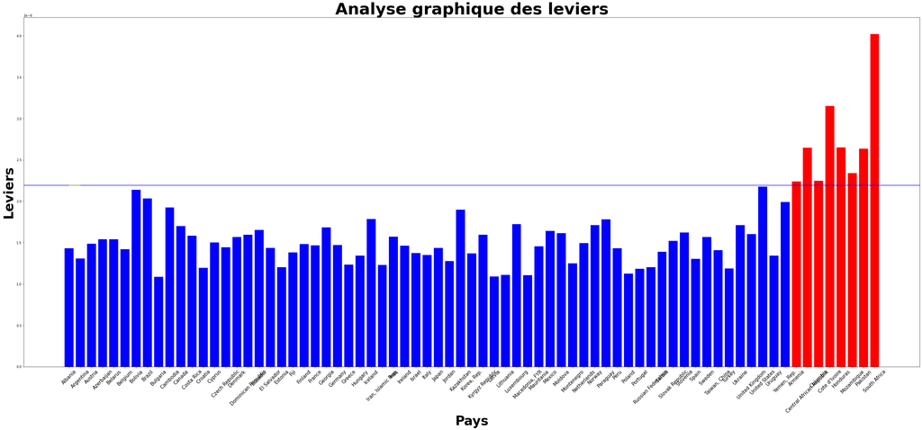

```python
#Visualisation des leviers du Modèle 1 par pays avec représentation du seuil
plt.figure(figsize=(50,20))

plt.bar(gb_lev_max.loc[gb_lev_max['levier'] <= seuil_levier]['pays'],

        gb_lev_max.loc[gb_lev_max['levier'] <= seuil_levier]['levier'], color='b')
plt.bar(gb_lev_max.loc[gb_lev_max['levier'] > seuil_levier]['pays'],
        gb_lev_max.loc[gb_lev_max['levier'] > seuil_levier]['levier'], color='r')
plt.axhline(y=seuil_levier, color='b', linestyle='-')
plt.plot( [seuil_levier, seuil_levier], color='y')
plt.xticks(fontsize=15,rotation=45)
plt.xlabel('Pays', fontsize=40, fontweight='bold')
plt.ylabel('Leviers', fontsize=40, fontweight='bold')
plt.title('Analyse graphique des leviers', fontsize=50, fontweight='bold')

plt.savefig('p7_figures/levier.jpg')
plt.show()
```

Pour sélectionner les points pour lesquels le levier est supérieur au seuil, on exécute la ligne suivante :

```python
#les valeurs superieurs au seuil
#pays concernés par les valeures atypiques
data_seuil=elast_gb_final.loc[elast_gb_final['levier'] > seuil_levier]
data_seuil.pays.unique()
```

```
array(['Armenia', 'Central African Republic', "Cote d'Ivoire", 'Colombia',
       'Honduras', 'Mozambique', 'Pakistan', 'South Africa'], dtype=object)
```

```python
data_seuil
```

|  | pays | income | revenue_moyen | gini | c_i_parent | levier | obs |
| --- | --- | --- | --- | --- | --- | --- | --- |
| 100000 | Armenia | 366.6178 | 1628.382785 | 0.270404 | 1 | 0.000002 | 100001 |
| 100001 | Armenia | 366.6178 | 1628.382785 | 0.270404 | 1 | 0.000002 | 100002 |
| 100002 | Armenia | 366.6178 | 1628.382785 | 0.270404 | 1 | 0.000002 | 100003 |
| 100003 | Armenia | 366.6178 | 1628.382785 | 0.270404 | 1 | 0.000002 | 100004 |
| 100004 | Armenia | 366.6178 | 1628.382785 | 0.270404 | 1 | 0.000002 | 100005 |
| ... | ... | ... | ... | ... | ... | ... | ... |
| 3649995 | South Africa | 82408.5500 | 5617.904880 | 0.673048 | 100 | 0.000004 | 3649996 |
| 3649996 | South Africa | 82408.5500 | 5617.904880 | 0.673048 | 100 | 0.000004 | 3649997 |
| 3649997 | South Africa | 82408.5500 | 5617.904880 | 0.673048 | 100 | 0.000004 | 3649998 |
| 3649998 | South Africa | 82408.5500 | 5617.904880 | 0.673048 | 100 | 0.000004 | 3649999 |
| 3649999 | South Africa | 82408.5500 | 5617.904880 | 0.673048 | 100 | 0.000004 | 3650000 |

160000 rows × 7 columns

```python
data_seuil.c_i_parent.unique()
```

```
array([  1,   2,  99, 100,   3,   4,   5,   6,   7,   8,   9,  10,  11,
        12,  13,  14,  15,  16,  17,  92,  84,  85,  86,  87,  90,  93,
        98,  88,  91,  95,  94,  96,  89,  97,  18,  19,  20,  21,  22,
        23,  24,  25,  26,  27,  28,  29,  30,  31,  32,  34,  35,  36,
        37,  38,  39,  40,  41,  42,  43,  44,  45,  46,  47,  48,  51,
        52,  53,  54,  56,  57,  58,  59,  60,  61,  62,  63,  64,  65,
        66,  68,  70,  33,  49,  50,  55,  67,  71,  72,  74,  80,  83,
        69,  73,  75,  78,  82,  76,  81,  77,  79], dtype=int64)
```

```python
data_seuil.describe()
```

|  | income | revenue_moyen | gini | c_i_parent | levier | obs |
| --- | --- | --- | --- | --- | --- | --- |
| count | 160000.000000 | 160000.000000 | 160000.000000 | 160000.000000 | 1.600000e+05 | 1.600000e+05 |
| mean | 2778.123868 | 2497.638200 | 0.523879 | 50.500000 | 2.803887e-06 | 1.925934e+06 |
| std | 7431.815837 | 2277.738440 | 0.130905 | 34.756403 | 5.159747e-07 | 1.345826e+06 |
| min | 34.555264 | 399.835204 | 0.270404 | 1.000000 | 2.199727e-06 | 1.000010e+05 |
| 25% | 300.644870 | 399.835204 | 0.420725 | 15.000000 | 2.372594e-06 | 6.210008e+05 |
| 50% | 672.996100 | 887.839279 | 0.566071 | 50.500000 | 2.584354e-06 | 1.477990e+06 |
| 75% | 1951.635600 | 5617.904880 | 0.673048 | 86.000000 | 3.245369e-06 | 3.610000e+06 |
| max | 82408.550000 | 5617.904880 | 0.673048 | 100.000000 | 4.019693e-06 | 3.650000e+06 |

```python
data_seuil.income.unique()
```

```
array([3.66617800e+02, 5.35327330e+02, 6.11645600e+02, 6.58339400e+02,
       6.90847100e+02, 7.21910000e+02, 7.53834800e+02, 7.84914000e+02,
       8.09087600e+02, 8.30590940e+02, 8.52458900e+02, 8.68941160e+02,
       8.85392760e+02, 9.01400450e+02, 9.16818500e+02, 9.30398440e+02,
       9.44147900e+02, 9.60319460e+02, 9.73621100e+02, 9.85938400e+02,
       1.00125635e+03, 1.01545060e+03, 1.03247700e+03, 1.04570460e+03,
       1.05777760e+03, 1.06918310e+03, 1.08107190e+03, 1.09288550e+03,
       1.10824370e+03, 1.12062350e+03, 1.13312830e+03, 1.14691090e+03,
       1.16265990e+03, 1.17823600e+03, 1.19389540e+03, 1.20813050e+03,
       1.22353030e+03, 1.23889510e+03, 1.25388590e+03, 1.26892250e+03,
       1.28183940e+03, 1.29642420e+03, 1.31454570e+03, 1.32777710e+03,
       1.34283730e+03, 1.35982480e+03, 1.37778910e+03, 1.39450280e+03,
       1.41109840e+03, 1.42815540e+03, 1.44647960e+03, 1.46258040e+03,
       1.47844790e+03, 1.49209290e+03, 1.50830600e+03, 1.52421280e+03,
       1.54433840e+03, 1.56122840e+03, 1.57927870e+03, 1.59705270e+03,
       1.61533460e+03, 1.62928300e+03, 1.64661730e+03, 1.66473200e+03,
       1.68639340e+03, 1.70909400e+03, 1.73085020e+03, 1.75007320e+03,
       1.77774850e+03, 1.80370540e+03, 1.82602780e+03, 1.85222900e+03,
       1.87959520e+03, 1.90690380e+03, 1.93223440e+03, 1.96078990e+03,
       1.99474660e+03, 2.02933200e+03, 2.06560700e+03, 2.09837500e+03,
       2.13294530e+03, 2.16903270e+03, 2.21510670e+03, 2.25884520e+03,
       2.30200460e+03, 2.35405880e+03, 2.40421120e+03, 2.45354470e+03,
       2.51282930e+03, 2.57003200e+03, 2.65357960e+03, 2.73850730e+03,
       2.83299120e+03, 2.93256050e+03, 3.06285570e+03, 3.22955370e+03,
       3.46666500e+03, 3.75860180e+03, 4.32028960e+03, 6.56615900e+03,
       4.09281300e+01, 6.27147140e+01, 7.95149200e+01, 9.14629400e+01,
       1.00001940e+02, 1.06962166e+02, 1.13776360e+02, 1.20580986e+02,
       1.28080230e+02, 1.36842940e+02, 1.43083650e+02, 1.49063170e+02,
       1.57198240e+02, 1.61768140e+02, 1.67944810e+02, 1.75857300e+02,
       1.82324310e+02, 1.88030870e+02, 1.95596040e+02, 2.02521620e+02,
       2.09514650e+02, 2.18346560e+02, 2.25044160e+02, 2.32545500e+02,
       2.40725170e+02, 2.48794590e+02, 2.57136870e+02, 2.64137480e+02,
       2.72083340e+02, 2.79924840e+02, 2.88109600e+02, 2.95672500e+02,
       3.02739380e+02, 3.09869100e+02, 3.17928680e+02, 3.23905430e+02,
       3.31781800e+02, 3.41114720e+02, 3.50443150e+02, 3.59500030e+02,
       3.68888520e+02, 3.78337400e+02, 3.86365230e+02, 3.95909850e+02,
       4.02867070e+02, 4.09407040e+02, 4.17424400e+02, 4.25404750e+02,
       4.32774440e+02, 4.41093700e+02, 4.51459260e+02, 4.59984070e+02,
       4.69028140e+02, 4.79668430e+02, 4.90556060e+02, 4.98760680e+02,
       5.10260070e+02, 5.21455800e+02, 5.31836600e+02, 5.43604000e+02,
```

[output cut: 145 more lines]

```
       1.64927140e+03, 1.70843910e+03, 1.76732810e+03, 1.82480650e+03,
       1.89498960e+03, 1.96912340e+03, 2.03094200e+03, 2.10078980e+03,
       2.18124500e+03, 2.25460640e+03, 2.33628420e+03, 2.42729660e+03,
       2.52003220e+03, 2.60731880e+03, 2.66313920e+03, 2.71159890e+03,
       2.76820480e+03, 2.84899200e+03, 2.94529370e+03, 3.06328560e+03,
       3.18679600e+03, 3.32209960e+03, 3.45653740e+03, 3.59861960e+03,
       3.74510200e+03, 3.89459600e+03, 4.05719700e+03, 4.22369600e+03,
       4.41377830e+03, 4.62095800e+03, 4.84014940e+03, 5.09110640e+03,
       5.34515100e+03, 5.57887160e+03, 5.85813100e+03, 6.23020600e+03,
       6.61796300e+03, 6.99770070e+03, 7.40639800e+03, 7.89035200e+03,
       8.37718100e+03, 8.96366000e+03, 9.58806400e+03, 1.02746040e+04,
       1.11044130e+04, 1.20936820e+04, 1.31222330e+04, 1.42816780e+04,
       1.55570470e+04, 1.71572230e+04, 1.94447050e+04, 2.17148930e+04,
       2.45535680e+04, 2.88580310e+04, 3.57502900e+04, 4.62973160e+04,
       8.24085500e+04])
```

```python
#on verifie le salaire maximal et le minimal et a quel pays ils appartiennent
d_max=data_seuil.income.max()
```

```python
data_seuil.loc[data_seuil.income==d_max]
```

|  | pays | income | revenue_moyen | gini | c_i_parent | levier | obs |
| --- | --- | --- | --- | --- | --- | --- | --- |
| 3649500 | South Africa | 82408.55 | 5617.90488 | 0.673048 | 14 | 0.000004 | 3649501 |
| 3649501 | South Africa | 82408.55 | 5617.90488 | 0.673048 | 19 | 0.000004 | 3649502 |
| 3649502 | South Africa | 82408.55 | 5617.90488 | 0.673048 | 20 | 0.000004 | 3649503 |
| 3649503 | South Africa | 82408.55 | 5617.90488 | 0.673048 | 23 | 0.000003 | 3649504 |
| 3649504 | South Africa | 82408.55 | 5617.90488 | 0.673048 | 26 | 0.000003 | 3649505 |
| ... | ... | ... | ... | ... | ... | ... | ... |
| 3649995 | South Africa | 82408.55 | 5617.90488 | 0.673048 | 100 | 0.000004 | 3649996 |
| 3649996 | South Africa | 82408.55 | 5617.90488 | 0.673048 | 100 | 0.000004 | 3649997 |
| 3649997 | South Africa | 82408.55 | 5617.90488 | 0.673048 | 100 | 0.000004 | 3649998 |
| 3649998 | South Africa | 82408.55 | 5617.90488 | 0.673048 | 100 | 0.000004 | 3649999 |
| 3649999 | South Africa | 82408.55 | 5617.90488 | 0.673048 | 100 | 0.000004 | 3650000 |

500 rows × 7 columns

l'afrique de sud comprend des revenues supperieures au seuil

```python
d_min=data_seuil.income.min()
d_min
```

```
34.555264
```

```python
data_seuil.loc[data_seuil.income==d_min]
```

|  | pays | income | revenue_moyen | gini | c_i_parent | levier | obs |
| --- | --- | --- | --- | --- | --- | --- | --- |
| 600000 | Cote d'Ivoire | 34.555264 | 399.835204 | 0.420725 | 1 | 0.000003 | 600001 |
| 600001 | Cote d'Ivoire | 34.555264 | 399.835204 | 0.420725 | 1 | 0.000003 | 600002 |
| 600002 | Cote d'Ivoire | 34.555264 | 399.835204 | 0.420725 | 1 | 0.000003 | 600003 |
| 600003 | Cote d'Ivoire | 34.555264 | 399.835204 | 0.420725 | 1 | 0.000003 | 600004 |
| 600004 | Cote d'Ivoire | 34.555264 | 399.835204 | 0.420725 | 1 | 0.000003 | 600005 |
| ... | ... | ... | ... | ... | ... | ... | ... |
| 600495 | Cote d'Ivoire | 34.555264 | 399.835204 | 0.420725 | 68 | 0.000002 | 600496 |
| 600496 | Cote d'Ivoire | 34.555264 | 399.835204 | 0.420725 | 68 | 0.000002 | 600497 |
| 600497 | Cote d'Ivoire | 34.555264 | 399.835204 | 0.420725 | 70 | 0.000002 | 600498 |
| 600498 | Cote d'Ivoire | 34.555264 | 399.835204 | 0.420725 | 85 | 0.000003 | 600499 |
| 600499 | Cote d'Ivoire | 34.555264 | 399.835204 | 0.420725 | 93 | 0.000003 | 600500 |

500 rows × 7 columns

```python
elast_gb_final.income.mean()
```

```
8578.10883807429
```

la cote d'ivore est le pays qui contien les reveues les plus inferieures au seuils

## Calculez les résidus studentisés

on calculer les résidus studentisés, sachant que le seuil pour les résidus studentisés est une loi de Student à n-p-1 degrés de liberté :

```python
elast_gb_final['rstudent'] = reg_log_cp.get_influence().resid_studentized_internal
seuil_rstudent = t.ppf(1-alpha/2,n-p-1)
seuil_rstudent
```

```
1.9599646344784794
```

```python
#les valeurs superieurs au seuil
#pays concernés par les valeures atypiques
data_seuil_rs=elast_gb_final.loc[elast_gb_final['rstudent'] > seuil_rstudent]
data_seuil_rs.pays.unique()
```

```
array(['Albania', 'Argentina', 'Armenia', 'Austria', 'Azerbaijan',
       'Belgium', 'Bulgaria', 'Belarus', 'Bolivia', 'Brazil',
       'Central African Republic', 'Canada', "Cote d'Ivoire", 'Colombia',
       'Costa Rica', 'Cyprus', 'Czech Republic', 'Germany', 'Denmark',
       'Dominican Republic', 'Ecuador', 'Spain', 'Estonia', 'Finland',
       'Fiji', 'France', 'United Kingdom', 'Georgia', 'Greece',
       'Honduras', 'Croatia', 'Hungary', 'Ireland', 'Iran, Islamic Rep.',
       'Iraq', 'Iceland', 'Israel', 'Italy', 'Jordan', 'Japan',
       'Kazakhstan', 'Kyrgyz Republic', 'Cambodia', 'Korea, Rep.',
       'Lithuania', 'Luxembourg', 'Latvia', 'Moldova', 'Mexico',
       'Macedonia, FYR', 'Montenegro', 'Mozambique', 'Mauritania',
       'Netherlands', 'Norway', 'Pakistan', 'Peru', 'Poland', 'Portugal',
       'Paraguay', 'Russian Federation', 'El Salvador', 'Serbia',
       'Slovak Republic', 'Slovenia', 'Sweden', 'Turkey', 'Taiwan, China',
       'Ukraine', 'Uruguay', 'United States', 'Yemen, Rep.',
       'South Africa'], dtype=object)
```

```python
data_seuil_rs
```

|  | pays | income | revenue_moyen | gini | log_income | log_revenue_moyen | c_i_parent | obs | levier | rstudent |
| --- | --- | --- | --- | --- | --- | --- | --- | --- | --- | --- |
| 47000 | Albania | 5860.9170 | 2994.829902 | 0.311509 | 8.676061 | 8.004643 | 5 | 47001 | 0.000001 | 2.000199 |
| 47001 | Albania | 5860.9170 | 2994.829902 | 0.311509 | 8.676061 | 8.004643 | 7 | 47002 | 0.000001 | 1.967775 |
| 47002 | Albania | 5860.9170 | 2994.829902 | 0.311509 | 8.676061 | 8.004643 | 7 | 47003 | 0.000001 | 1.967775 |
| 47003 | Albania | 5860.9170 | 2994.829902 | 0.311509 | 8.676061 | 8.004643 | 7 | 47004 | 0.000001 | 1.967775 |
| 47500 | Albania | 6231.0996 | 2994.829902 | 0.311509 | 8.737308 | 8.004643 | 8 | 47501 | 0.000001 | 2.045904 |
| ... | ... | ... | ... | ... | ... | ... | ... | ... | ... | ... |
| 3649995 | South Africa | 82408.5500 | 5617.904880 | 0.673048 | 11.319444 | 8.633714 | 100 | 3649996 | 0.000004 | 4.507799 |
| 3649996 | South Africa | 82408.5500 | 5617.904880 | 0.673048 | 11.319444 | 8.633714 | 100 | 3649997 | 0.000004 | 4.507799 |
| 3649997 | South Africa | 82408.5500 | 5617.904880 | 0.673048 | 11.319444 | 8.633714 | 100 | 3649998 | 0.000004 | 4.507799 |
| 3649998 | South Africa | 82408.5500 | 5617.904880 | 0.673048 | 11.319444 | 8.633714 | 100 | 3649999 | 0.000004 | 4.507799 |
| 3649999 | South Africa | 82408.5500 | 5617.904880 | 0.673048 | 11.319444 | 8.633714 | 100 | 3650000 | 0.000004 | 4.507799 |

96406 rows × 10 columns

```python
#grouper le dataframe en pays par maximum des leviers pour avoir moins de données pour faciliter le rendu

gb_res_mean=elast_gb_final.groupby('pays')['rstudent'].mean().reset_index()
```

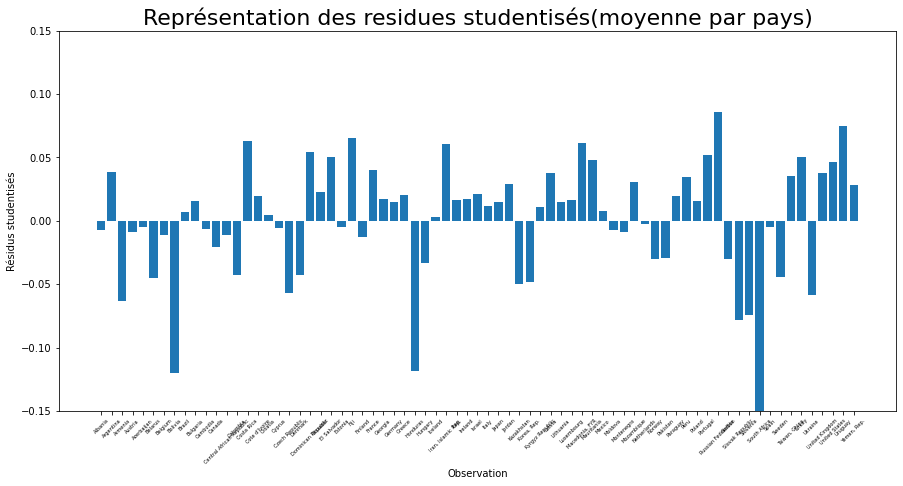

```python
plt.figure(figsize=(15,7))
plt.bar(gb_res_mean['pays'], gb_res_mean['rstudent'])
plt.xticks(fontsize=5,rotation=45)
plt.xlabel('Observation',fontsize=10)
plt.ylabel('Résidus studentisés',fontsize=10)

plt.title('Représentation des residues studentisés(moyenne par pays)', fontsize=22)
plt.ylim(-0.15,0.15)
plt.plot( [seuil_rstudent, seuil_rstudent], color='r')
plt.plot( [-seuil_rstudent, -seuil_rstudent], color='r')
plt.savefig('p7_figures/residues_mean.jpg')
plt.show()
```

```python
#grouper le dataframe en pays par maximum et minimum des residus  pour avoir moins de données pour faciliter le rendu

gb_res_max=elast_gb_final.groupby('pays')['rstudent'].max().reset_index()
gb_res_min=elast_gb_final.groupby('pays')['rstudent'].min().reset_index()
```

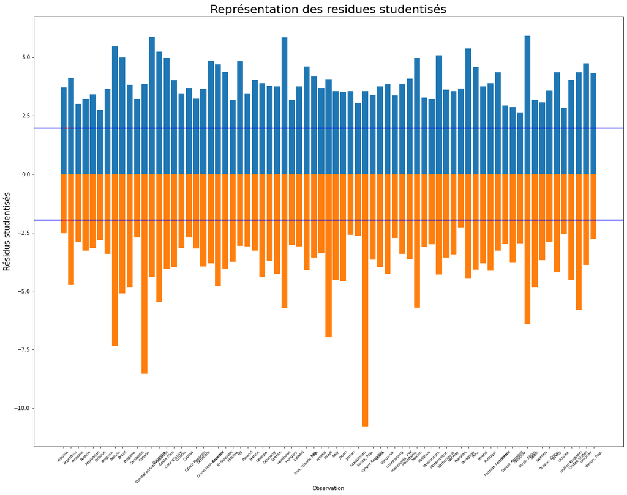

```python
plt.figure(figsize=(20,15))
plt.bar(gb_res_max['pays'], gb_res_max['rstudent'])
plt.bar(gb_res_min['pays'], gb_res_min['rstudent'])
plt.xticks(fontsize=7,rotation=45)
plt.xlabel('Observation')
plt.ylabel('Résidus studentisés',fontsize=15)
plt.axhline(y=seuil_rstudent, color='b', linestyle='-')

plt.title('Représentation des residues studentisés', fontsize=22)
plt.axhline(y=-seuil_rstudent, color='b', linestyle='-')
plt.axhline(y=-seuil_rstudent, color='b', linestyle='-')
plt.plot( [seuil_rstudent, seuil_rstudent], color='r')
plt.plot( [-seuil_rstudent, -seuil_rstudent], color='r')
plt.savefig('p7_figures/residues_maximals et minimals par pays.jpg')
plt.show()
```

## Déterminez la distance de Cook

Pour trouver la distance de Cook, nous exécutons ceci :

```python
influence = reg_log_cp.get_influence().summary_frame()
influence
#Le seuil de la distance de Cook est de n-p.
```

[output not shown]

```python
elast_gb_fini['dcooks'] = influence['cooks_d']
seuil_dcook = 4/(n-p)
seuil_dcook
```

[output not shown]

```python
data_seuil_dcook=elast_gb_fini.loc[elast_gb_fini['dcooks'] > seuil_dcook]
data_seuil_dcook
```

[output not shown]

On peut détecter les observations influentes comme ceci :

```python
#grouper le dataframe en pays par distance maximal des observations influante pour avoir moins de données pour faciliter le rendu

gb_cook_max=elast_gb_final.groupby('pays')['dcooks'].max().reset_index()
```

```python
plt.figure(figsize=(20,10))
plt.bar(gb_cook_max['pays'], gb_cook_max['dcooks'])

plt.xticks(fontsize=5,rotation=45)
plt.xlabel('Observation')
plt.ylabel('distance de cook')
plt.plot( [seuil_dcook, seuil_dcook], color='r')


plt.savefig('p7_figures/distance_de_cook.jpg')
plt.show()
```

[output not shown]

[output not shown]

```python
gb_cook_max.pays()
```

```python
# On ne retire des points qu'après avoir vérifié qu'ils sont effectivement atypiques, voire aberrants, au vu du modèle estimé
```

## Vérifier la colinéarité des variables

Une autre chose à vérifier est l'éventuelle colinéarité approchée des variables :

```python
variables = reg_log_cp.model.exog
[variance_inflation_factor(variables, i) for i in np.arange(1,variables.shape[1])]
#Ici, tous les coefficients sont inférieurs à 10, il n'y a donc pas de problème de colinéarité.
```

```
[1.1497814887246938, 1.1497814887248172, 0.9999999999999998]
```

## Testez l’homoscédasticité

On peut également tester l’homoscédasticité (c'est-à-dire la constance de la variance) des résidus :

```python
_, pval, __, f_pval = statsmodels.stats.diagnostic.het_breuschpagan(reg_log_cp.resid, variables)
print('p value test Breusch Pagan:', pval)
```

```
p value test Breusch Pagan: 0.0
```

## Testez la normalité des résidus

pour tester la normalité des résidus, on fait un test de Shapiro-Wilk adapté à la tail de nos données

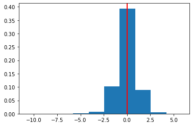

```python
plt.hist(elast_gb_final.rstudent, density=True)
plt.axvline(x=elast_gb_final["rstudent"].mean(), label='Moyenne', linestyle='-', linewidth=2, color='red')
plt.axvline(x=elast_gb_final["rstudent"].median(), label='Médiane', linestyle='--', linewidth=2 ,color='red')
plt.show()
```

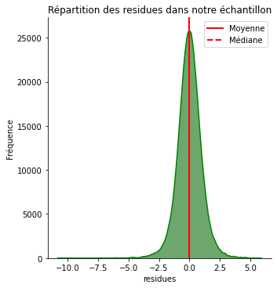

```python
sns.displot(data=elast_gb_final, x="rstudent", kde=True ,color='green')

plt.axvline(x=elast_gb_final["rstudent"].mean(), label='Moyenne', linestyle='-', linewidth=2, color='red')
plt.axvline(x=elast_gb_final["rstudent"].median(), label='Médiane', linestyle='--', linewidth=2 ,color='red')
plt.xlabel('residues')
plt.ylabel('Fréquence')
plt.title('Répartition des residues dans notre échantillon')
#plt.ylim(0,20)
plt.legend()


plt.savefig('p7_figures/Distribution_rstudent.jpg')

plt.show()
```

```python
elast_gb_final
```

[output not shown]

```python
shapiro(reg_log_cp.resid)
```

```
ShapiroResult(statistic=0.9763796329498291, pvalue=0.0)
```

```python
#le nombre de données est>5000 , on fait le test d'adequation à une loie normale  avec le test Kolmogorv-Smirnov
from scipy.stats import t, shapiro, ks_2samp

X = reg_log_cp.resid
Xbar = np.mean(X)
Xsprime = np.std(X)

ks_2samp(X, list(np.random.normal(Xbar, Xsprime, 3650000)))
```

```
KstestResult(statistic=0.033364657534246556, pvalue=0.0)
```

la p value etant de 0.0 <5% On peut rejeter l'hypothese H0 donc les residues ne suivent pas une loi normale mais vue la taille de l'échantillon et la distribution presque symétrique on peut pas remettre remettre en cause la performance de ce model

### graphique q-q

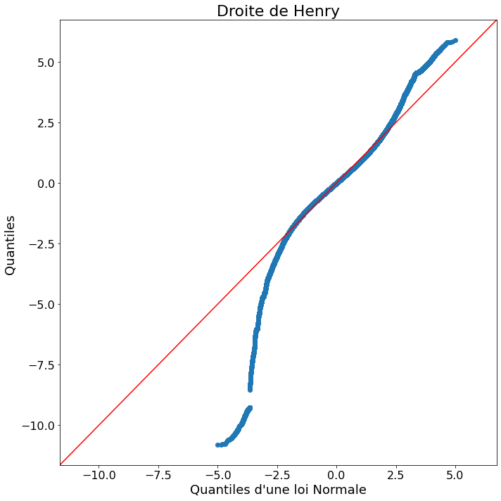

```python
# Droite de Henry
fig, ax = plt.subplots(figsize=(10, 10))

sm.qqplot(X, line='45', fit=True, ax=ax)

plt.ylabel('Quantiles ', fontsize=18)
plt.yticks(fontsize=16)
plt.xlabel('Quantiles d\'une loi Normale',fontsize=18)
plt.xticks(fontsize=16)
plt.title('Droite de Henry', fontsize=22)

plt.tight_layout()

plt.savefig('p7_figures/graphique_q_q.png')
plt.show()
```